Political Giving Analysis of Virginia’s Personal Contributions by Romulo Cabeza Date: May 23, 2015 ========================================================

```
##  [1] "cmte_id"           "cand_id"           "cand_nm"
##  [4] "contbr_nm"         "contbr_city"       "contbr_st"
##  [7] "contbr_zip"        "contbr_employer"   "contbr_occupation"
## [10] "contb_receipt_amt" "contb_receipt_dt"  "receipt_desc"
## [13] "memo_cd"           "memo_text"         "form_tp"
## [16] "file_num"          "tran_id"           "election_tp"
```

```
##  [1] Romney, Mitt                   Obama, Barack
##  [3] Gingrich, Newt                 Pawlenty, Timothy
##  [5] Bachmann, Michele              Paul, Ron
##  [7] McCotter, Thaddeus G           Roemer, Charles E. 'Buddy' III
##  [9] Perry, Rick                    Cain, Herman
## [11] Johnson, Gary Earl             Santorum, Rick
## [13] Huntsman, Jon                  Stein, Jill
## 14 Levels: Bachmann, Michele Cain, Herman Gingrich, Newt ... Stein, Jill
```

```
## 'data.frame':    196289 obs. of  18 variables:
##  $ cmte_id          : Factor w/ 15 levels "C00410118","C00431171",..: 2 2 2 2 2 2 2 2 2 2 ...
##  $ cand_id          : Factor w/ 14 levels "P00003608","P20002523",..: 14 14 14 14 14 14 14 14 14 14 ...
##  $ cand_nm          : Factor w/ 14 levels "Bachmann, Michele",..: 12 12 12 12 12 12 12 12 12 12 ...
##  $ contbr_nm        : Factor w/ 52115 levels "[BOOKER] JAMES, SALLY AND JOHN",..: 43676 43676 43684 43684 43689 43701 44648 44633 45464 45469 ...
##  $ contbr_city      : Factor w/ 964 levels "","-- SELECT A CITY --",..: 181 181 737 737 364 777 531 887 423 556 ...
##  $ contbr_st        : Factor w/ 1 level "VA": 1 1 1 1 1 1 1 1 1 1 ...
##  $ contbr_zip       : int  229119096 229119096 232261745 232261745 229401802 241532646 231032912 221814034 228014027 221014900 ...
##  $ contbr_employer  : Factor w/ 20101 levels ""," JOHNS AND BHATIA ENGINEERING",..: 4617 4617 8323 8323 8778 8778 14335 6714 5779 4329 ...
##  $ contbr_occupation: Factor w/ 10630 levels "","(PART-TIME) SALES CONSULTANT & WRITER",..: 312 312 4399 4399 4707 4707 7951 2917 3649 663 ...
##  $ contb_receipt_amt: num  200 200 103 80 100 250 500 250 500 2500 ...
##  $ contb_receipt_dt : Factor w/ 647 levels "1-Apr-11","1-Apr-12",..: 588 324 324 508 152 508 508 365 88 426 ...
##  $ receipt_desc     : Factor w/ 14 levels "","REATTRIBUTION / REDESIGNATION REQUESTED",..: 1 1 1 1 1 1 1 1 1 1 ...
##  $ memo_cd          : Factor w/ 2 levels "","X": 1 1 1 1 1 1 1 1 1 1 ...
##  $ memo_text        : Factor w/ 104 levels "","*","* EARMARKED CONTRIBUTION: SEE BELOW",..: 1 1 1 1 1 1 1 1 1 1 ...
##  $ form_tp          : Factor w/ 3 levels "SA17A","SA18",..: 1 1 1 1 1 1 1 1 1 1 ...
##  $ file_num         : int  896743 896743 896743 896743 896743 896743 896743 896743 896743 896743 ...
##  $ tran_id          : Factor w/ 196269 levels "1000000071:1414618",..: 157520 159010 159003 159409 158388 159624 159166 158953 158157 159179 ...
##  $ election_tp      : Factor w/ 7 levels "","G2008","G2012",..: 7 7 7 3 7 3 3 3 7 3 ...
```

### What is the structure of your dataset?

The data is a database of donations, transfer and refunds of funds to presidential candidates in the 2012 election. It is organized by date and donations given to candidates in the primary (for all Republicans) and general election (for the eventual Republican nominee, Mitt Romney and Democratic incumbent Barack Obama). There is geographic information (zip code, city), but it is not organized in an organized manner. The size of donations are nearly all between 0-2500.

There were 52,115 individuals and 14 candidates. Of the the 52,115 there were some duplications due to transactions that were transfers and necessitated another receipt, or refunds that necessitated another receipt.

There is no easily identifiale party label (Dems vs. Reps.)

The major variables

contbr_receipt_amt: donation size contbr_receipt_dt: when a donation was made cand_nm: candidate

### What is/are the main feature(s) of interest in your dataset?

I want to see if the giving rates (amounts, sizes) conform to conventional political wisdom. So, I want to know about the size of the donations, how many, and during what stage of the election cycle.

The data has personal information for individual givers including employer, profession, location.

Important variables to be discussed: -size of the political donations -dates of giving -Profession of giver -number of personal donations to a given candidate -

I’m most also interested in the giving rates by people that have a chosen profession. This insiht could be used to understand how subsets of the population reacted to certain campaign rhetoric, during the 2012 campaign. For instance, did a negative ad in June of 2012 cause a particular inflection point in the personal giving rates of certain types of individuals that deviates significantly from the overall personal contribution patterns?

### New Variables That were necessary for the analysis

1. party labels: I created a party function to identify the party of the candidates and label them appropriately.
2. running total: I created a running_count variable for each candidate based on the amount given per day. This came as a result of some preliminary analysis (ommitted for brevity), which showed the tracking the number of contributions by scatter plot is not tenable. It is easy to overplot. Because so many of the data points are clustered in a few bands (100, 250, 1000, etc.), its not easy to compare where candidates are when you facet_wrap.
3. zip code/county: I created a five-digit zip code in order to start to consolidate all of the expanded zip codes (9 digit) and mispelled towns. If you look for unique contributor cities, there are 964. A quick google search finds that there are 38 cities and 191 towns in virginia. Glancing at the data there are a lot of mispelled city names and abbreviations. Its a nightmare. So I created a five digit zip code variable from the nine-digit mailing zip code, and then I use a zip code database to match the five digit zip codes to the respective counties.

In order to obtain the zip code I downloaded a zip code database from: http://www.unitedstateszipcodes.org/zip-code-database/

4. I had to format the date variable.
5. PIFS Code: For Visualizing the data I needed to match the county to specific PIFS codes and data. This involved some data wrangling.

see more: http://en.wikipedia.org/wiki/FIPS_county_code

### Of the features you investigated, were there any unusual distributions?

### Did you perform any operations on the data to tidy, adjust, or

### change the form of the data? If so, why did you do this?

I saw that there was some negative contributions. I investigated those a bit and fund that the data set has some folks that only got their money back. Its a small enough number that it won’t impact the overall findings. I was able to account for the information and document it.

I was able to get around the mispelling of cities but some individuals were inevitably counted twice because of mispellings. I can’t control for that. There is some built in human error in the data set.

## Understanding Overall Distribution of giving by candidates,

## and phases of the election, and number of total contributors

```
## [1] 0.4554911
```

```
## [1] 0.5435187
```

So 45.6% of the contributions were given in the primary,and 54.3% were given in the general election. Its important to note, that the primary election funds can also be transferred to other state candidates, the candidate who won the Rep. (e.g. Romney) primary, paying back debt, etc.

But the point is that other, types of giving elections, can be eliminated from future discussion.

### How much was given overall?

```
## [1] 0.5201263
```

```
## [1] 0.4798737
```

$18.1 (52%) million was given in Primaries and $16.7 (48%) million was given during the general election

### Initial observations:

The Primary had higher value of total personal contributions than to the general election , but there were more individuals contributions to the general than to the primaries, indicating a a higer higher participation. A lot of primary donations are transferable, to the general election but it was also used by Republicans to combat one another.

### Number of people who contributed and the candidates

```
## [1] 52033
```

```
##  [1] Romney, Mitt                   Obama, Barack
##  [3] Gingrich, Newt                 Pawlenty, Timothy
##  [5] Bachmann, Michele              Paul, Ron
##  [7] McCotter, Thaddeus G           Roemer, Charles E. 'Buddy' III
##  [9] Perry, Rick                    Cain, Herman
## [11] Johnson, Gary Earl             Santorum, Rick
## [13] Huntsman, Jon                  Stein, Jill
## 14 Levels: Bachmann, Michele Cain, Herman Gingrich, Newt ... Stein, Jill
```

### But there is an interesting hiccup..

When we lookat at the amount given under general and primary it is greater than one and divide by the total amount we find that it is greater than one?

```
## [1] 1.001133
```

Looking at the data we see that there contributions that are negative, indicating the total designated as primary or general election contributions are greater than the amount given. Lets explore more…

```
## [1] 1845
```

```
## Source: local data frame [10 x 3]
##
##              cand_nm total_refund_redeg n_ref_rec
## 1        Stein, Jill             -71.00         2
## 2       Cain, Herman            -300.00         1
## 3      Huntsman, Jon           -5000.00         2
## 4          Paul, Ron           -6260.22        15
## 5  Pawlenty, Timothy          -12287.20         7
## 6        Perry, Rick          -12500.00         5
## 7     Santorum, Rick          -14345.00        26
## 8     Gingrich, Newt          -50048.66        46
## 9      Obama, Barack         -258882.59      1362
## 10      Romney, Mitt         -510020.59       379
```

```
## [1] -869715.3
```

```
## Source: local data frame [6 x 4]
##
##                    receipt_desc total_refunds number_of_refunds
## 1      REDESIGNATION TO PRIMARY      -2300.00                 1
## 2 REDESIGNATION TO PRIMARY DEBT     -33299.12                22
## 3                                   -90719.62               132
## 4       REATTRIBUTION TO SPOUSE    -100006.24                70
## 5      REDESIGNATION TO GENERAL    -248828.22               166
## 6                        Refund    -394562.06              1454
## Variables not shown: mean_refund (dbl)
```

```
## Source: local data frame [7 x 2]
##
##                                                                     memo_text
## 1                                                    *OBAMA VICTORY FUND 2012
## 2                                                      CHECK RETURNED BY BANK
## 3 TRANSFER FROM ROMNEY VICTORY INC.; EXCESSIVE WILL BE CORRECTED ON NEXT DIST
## 4
## 5                                                   * OBAMA VICTORY FUND 2012
## 6                                                                CHARGED BACK
## 7                                           TRANSFER FROM ROMNEY VICTORY INC.
## Variables not shown: total_refund (dbl)
```

### How much did each candidate get

```
## Source: local data frame [14 x 3]
##
##                           cand_nm fundraising_total       party
## 1                   Obama, Barack       16822370.84    Democrat
## 2                    Romney, Mitt       15561867.80  Republican
## 3                       Paul, Ron         663751.80  Republican
## 4                  Santorum, Rick         429725.14  Republican
## 5                  Gingrich, Newt         404776.29  Republican
## 6                     Perry, Rick         229380.12  Republican
## 7                    Cain, Herman         192833.56  Republican
## 8               Pawlenty, Timothy         127862.17  Republican
## 9                   Huntsman, Jon         111910.71  Republican
## 10              Bachmann, Michele          76453.66  Republican
## 11             Johnson, Gary Earl          35250.94 Third Party
## 12 Roemer, Charles E. 'Buddy' III          10958.50  Republican
## 13                    Stein, Jill           8929.00 Third Party
## 14           McCotter, Thaddeus G            250.00  Republican
```

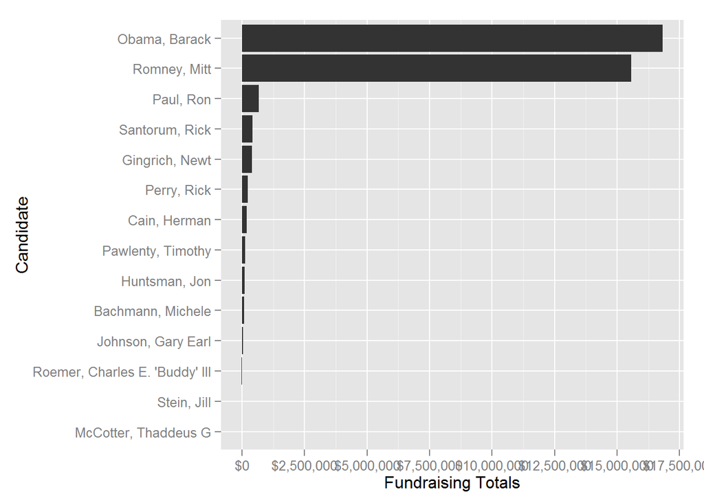

Obama, Romney, Paul, Santorum, and are the largest contributors. No larges surprises.

### Distribution of donations for each candidate

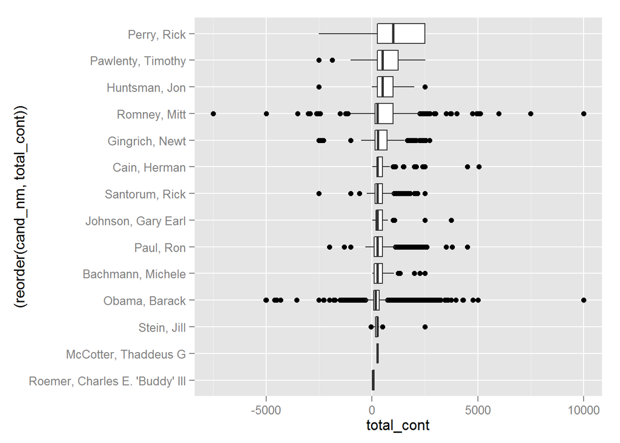

The negative contributions are back again! So there must be some folks who give negative money (e.g. gave and took it back)

```
## [1] 789
```

```
## [1] -416040.1
```

### Distribution of total persona gifts

Lets look at the overal distributions and the consider how they differ by party, and then by candidates.

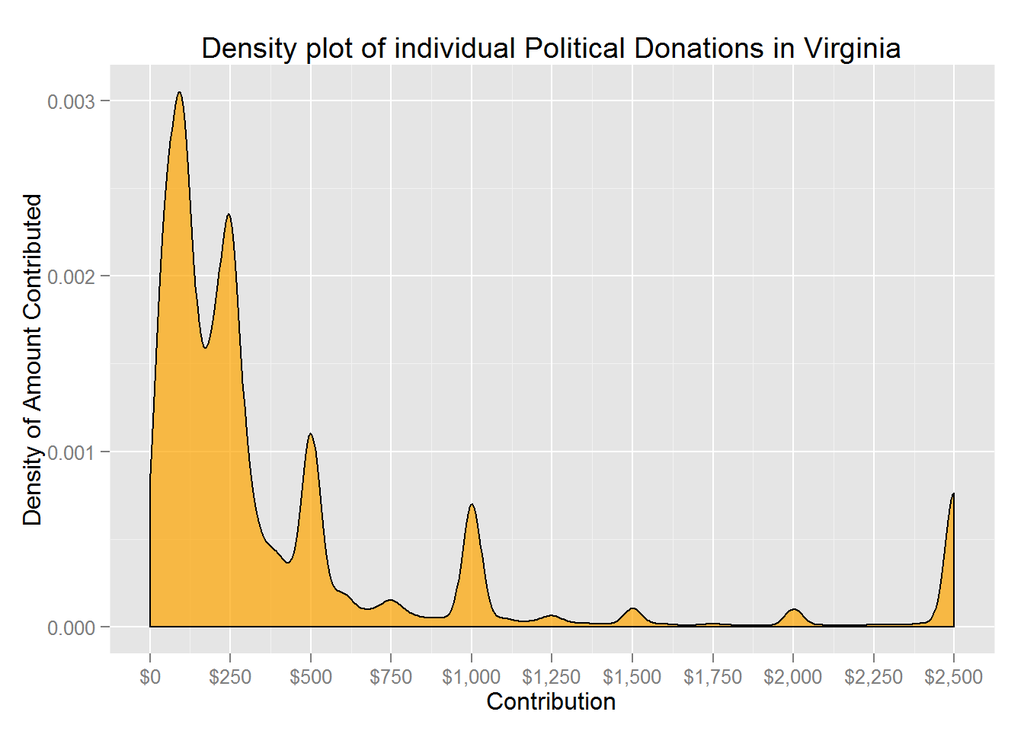

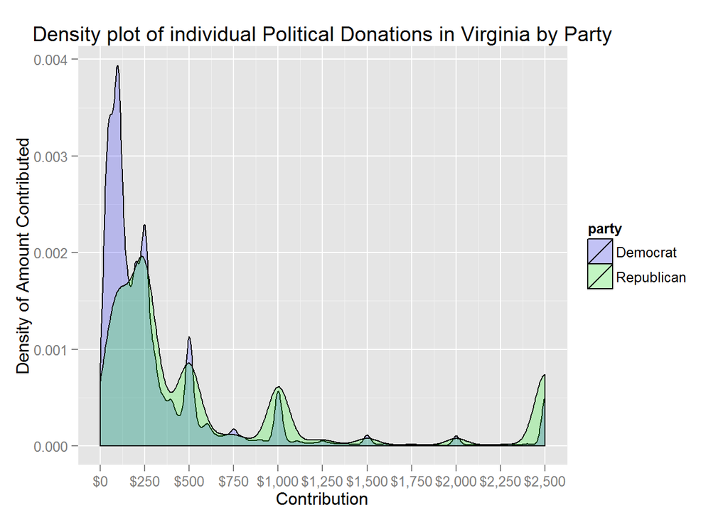

```
##    Min. 1st Qu.  Median    Mean 3rd Qu.    Max.
##    0.49  100.00  240.00  445.50  500.00 2500.00
```

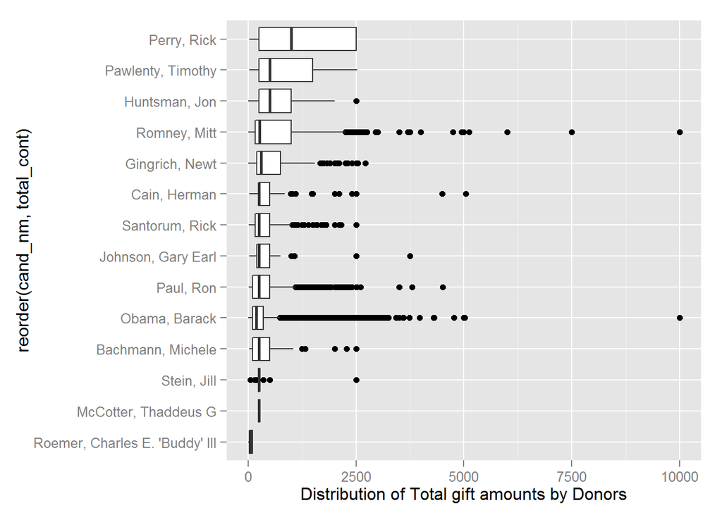

```
## cand_nm: Bachmann, Michele
##    Min. 1st Qu.  Median    Mean 3rd Qu.    Max.
##    20.0   100.0   250.0   338.3   493.8  2500.0
## --------------------------------------------------------
## cand_nm: Cain, Herman
##    Min. 1st Qu.  Median    Mean 3rd Qu.    Max.
##    20.0   233.5   250.0   493.2   500.0  5050.0
## --------------------------------------------------------
## cand_nm: Gingrich, Newt
##    Min. 1st Qu.  Median    Mean 3rd Qu.    Max.
##    0.49  200.00  300.00  605.70  750.00 2712.00
## --------------------------------------------------------
## cand_nm: Huntsman, Jon
##    Min. 1st Qu.  Median    Mean 3rd Qu.    Max.
##     4.0   250.0   500.0   835.1  1000.0  2500.0
## --------------------------------------------------------
## cand_nm: Johnson, Gary Earl
##    Min. 1st Qu.  Median    Mean 3rd Qu.    Max.
##    25.0   200.0   250.0   446.2   500.0  3750.0
## --------------------------------------------------------
## cand_nm: McCotter, Thaddeus G
##    Min. 1st Qu.  Median    Mean 3rd Qu.    Max.
##     250     250     250     250     250     250
## --------------------------------------------------------
## cand_nm: Obama, Barack
##    Min. 1st Qu.  Median    Mean 3rd Qu.    Max.
##     2.0    95.0   187.0   344.5   350.0 10000.0
## --------------------------------------------------------
## cand_nm: Paul, Ron
##    Min. 1st Qu.  Median    Mean 3rd Qu.    Max.
##     7.5   100.0   250.0   443.7   500.0  4512.0
## --------------------------------------------------------
## cand_nm: Pawlenty, Timothy
##    Min. 1st Qu.  Median    Mean 3rd Qu.    Max.
##    25.0   250.0   500.0   951.7  1500.0  2525.0
## --------------------------------------------------------
## cand_nm: Perry, Rick
##    Min. 1st Qu.  Median    Mean 3rd Qu.    Max.
##      30     250    1000    1247    2500    2500
## --------------------------------------------------------
## cand_nm: Roemer, Charles E. 'Buddy' III
##    Min. 1st Qu.  Median    Mean 3rd Qu.    Max.
##    1.00   25.00   50.00   62.26  100.00  100.00
## --------------------------------------------------------
## cand_nm: Romney, Mitt
##    Min. 1st Qu.  Median    Mean 3rd Qu.    Max.
##     3.0   165.0   259.9   670.8  1000.0 10000.0
## --------------------------------------------------------
## cand_nm: Santorum, Rick
##    Min. 1st Qu.  Median    Mean 3rd Qu.    Max.
##    10.0   160.0   250.0   469.8   500.0  2500.0
## --------------------------------------------------------
## cand_nm: Stein, Jill
##    Min. 1st Qu.  Median    Mean 3rd Qu.    Max.
##    50.0   237.5   250.0   321.4   250.0  2500.0
```

The above summarizes the distribution for the candidates. Unucccessful candidates had a higher proportion of large contributions, which impacted their mean contribution. This makes sense, since the contribution limit was $2,500 for 2012, and candidates with less contributions will be more impacted by the few large contributions.Some folks have total contributions of $5,000 indicating they gave the max in both the primary and general election.

### What is the distribution of gifts?

The question here is not the total distribution of gifts for candidates, but how much was given for EACH given donation

```
##     Min.  1st Qu.   Median     Mean  3rd Qu.     Max.
##     0.49   100.00   241.80   453.20   500.00 10000.00
```

```
##     Min.  1st Qu.   Median     Mean  3rd Qu.     Max.
##     0.49    28.00    56.00   196.80   152.50 10000.00
```

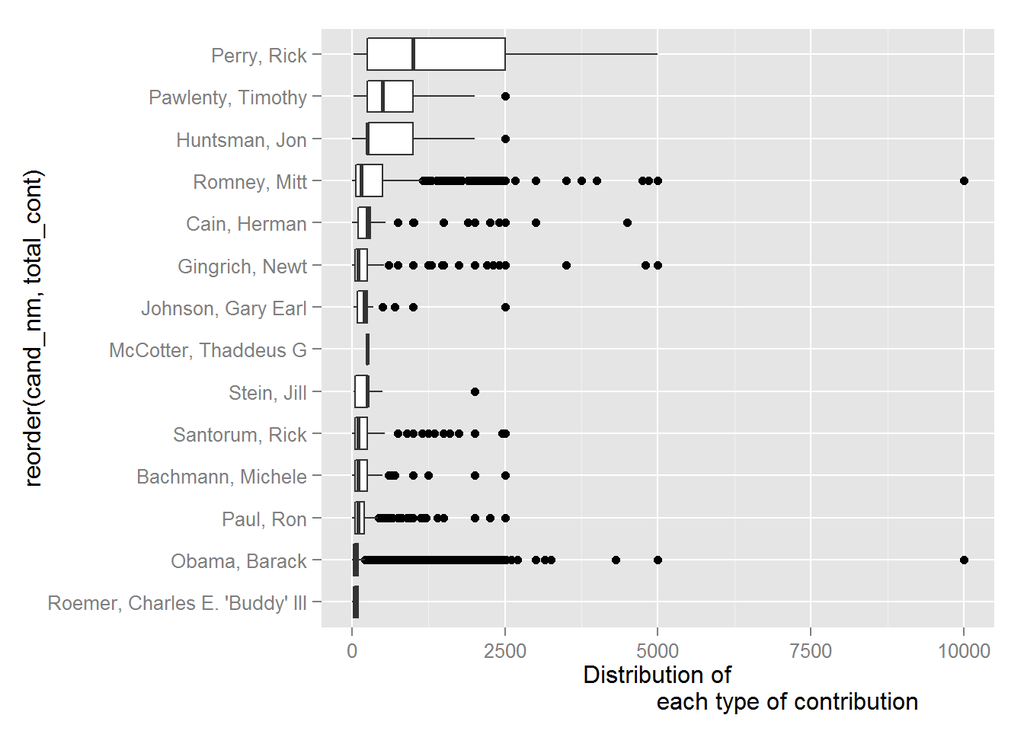

The boxplot “scrunches”" a bit, indicating that a a lot of individual contributors’ total come from giving multiple times this is especially true for Romney and Obama. Obama’s boxplot shrunk significantly, indicating that people were giving him small gifts, but some were repeating. Romney’s also shrunk, but the gifts were likely larger. removing the refunds makes boxplots more legible, and more indicative of the distribution.

# Geographic Analysis of personal contributions: ten largest counties

There are 135 unique counties in virginia. How many cities should we consider determinant? First lets get a quick understanding of the distribution of total giving by city, the NUMBERS given by city, and finally, the distribution of giving by the largest contributing cities

```
## [1] 0.8000971
```

```
## Source: local data frame [12 x 4]
##
##                   county total_contributions number_contributions
## 1         Fairfax County          12077922.6                23470
## 2       Arlington County           4377254.8                 8741
## 3        Alexandria City           2834293.9                 5242
## 4         Loudoun County           1786977.2                 4297
## 5       Albemarle County           1414358.6                 2846
## 6    Virginia Beach City            990394.2                 2398
## 7         Henrico County            959477.4                 2453
## 8  Prince William County            870506.6                 3004
## 9          Richmond City            849460.5                 1718
## 10   Chesterfield County            706952.7                 2076
## 11       Fauquier County            474863.4                  762
## 12          Norfolk City            401520.5                 1083
## Variables not shown: state_share (dbl)
```

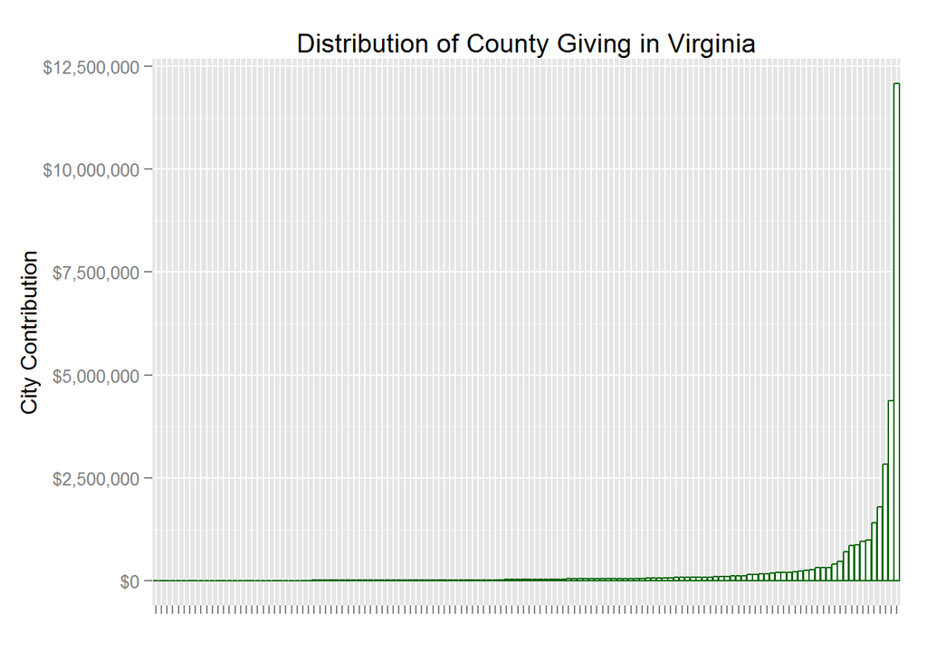

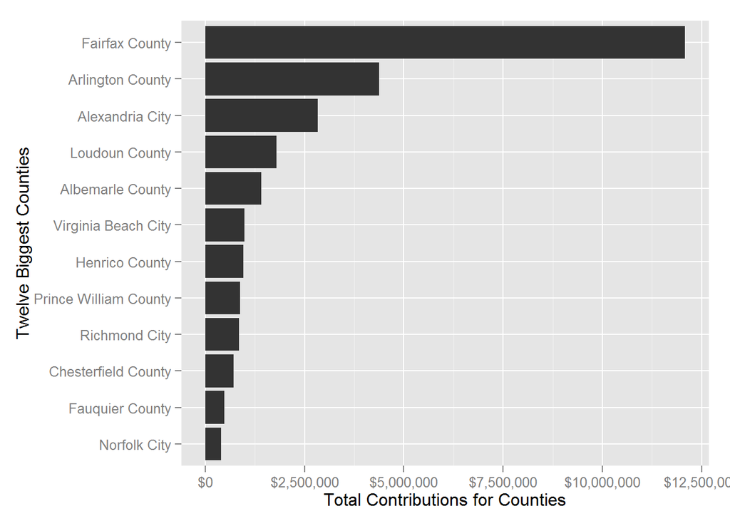

### A Visual Map of Giving By Virginia

I made a Chloropleth map of Virginia to demonstrate the concentration of Giving. As expected, the majority of political donations come from areas that border Washington, D.C. (the northeast corner is Fairfax, Arlington, Alexandria, and Loudon) These areas are the most affluent, and have a lot of people working politics, for the government, government contractors, or private sector that does work related to the federal government.

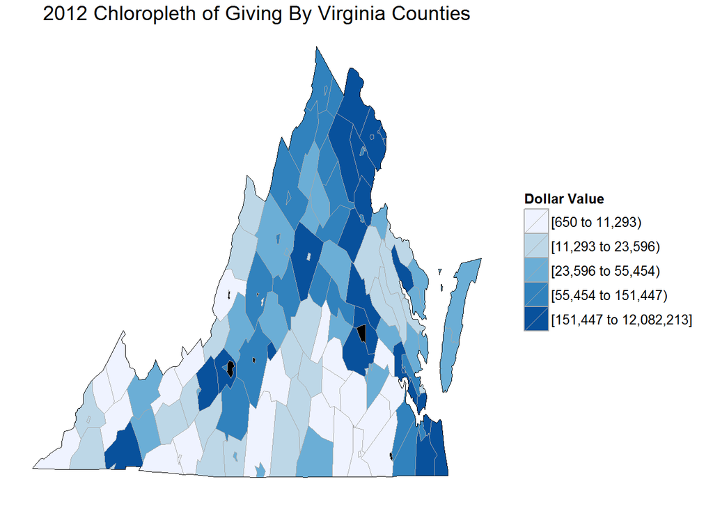

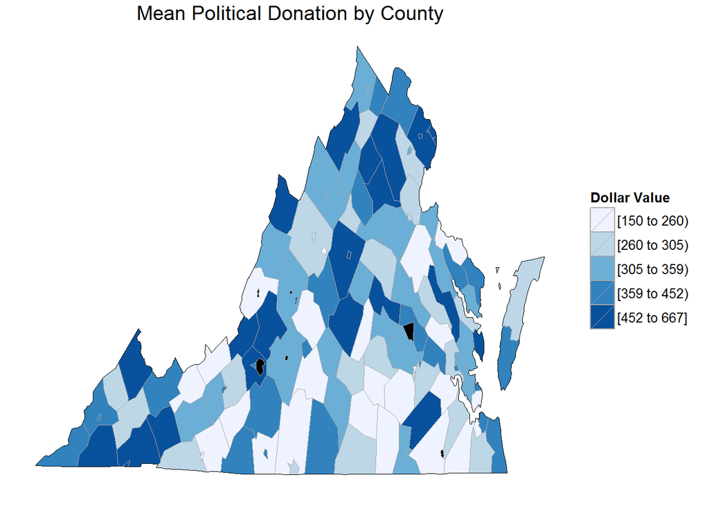

From the looks it seems we don’t need to consider many counties outside the top ten or so. It is a very long tailed data. Fairfax is by fair the largest county in the aggregate. Only 12 counties have one percent or more and make up eighty percent of giving.

### Density plot of giving in Dozen largest Counties

e.g. how do counties give?

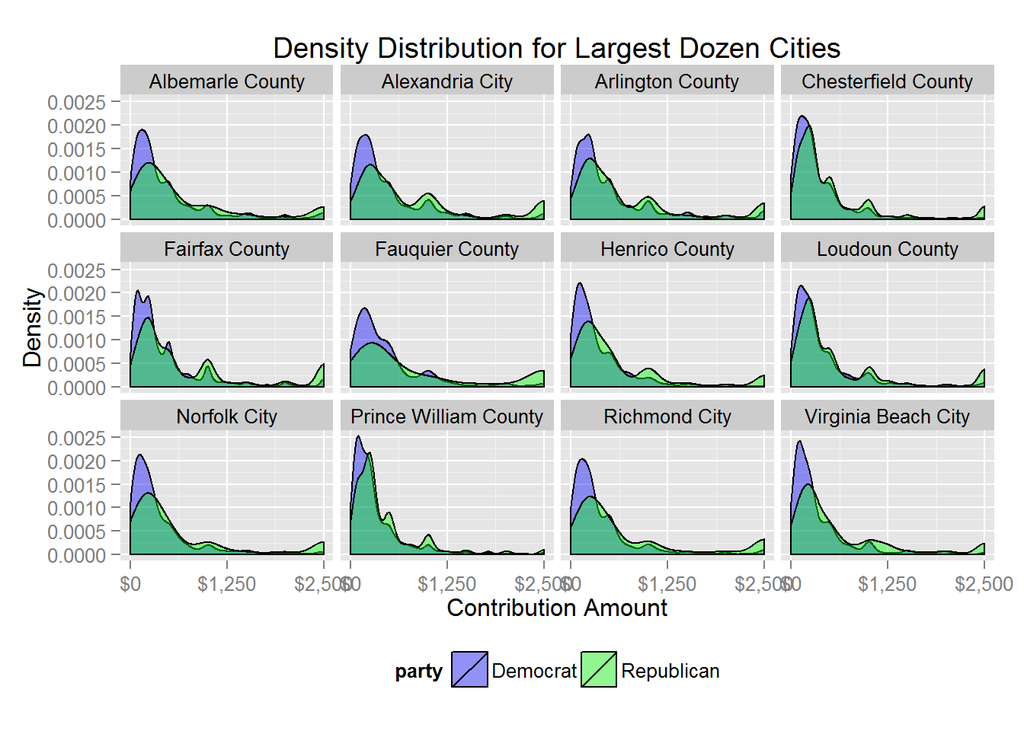

### Distribution of total personal gifts in largest 12 counties

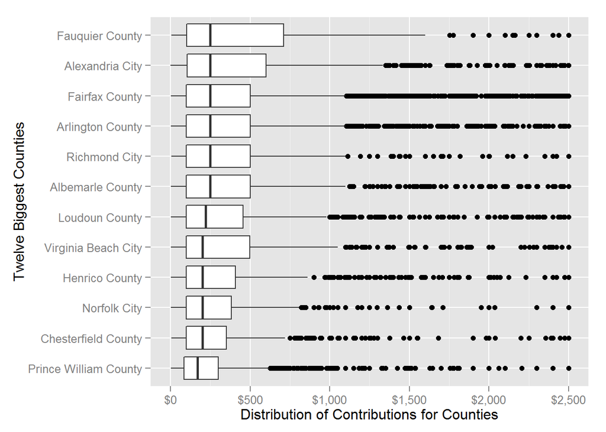

If we facet Wrap through the 12 largest towns, we can see that the distribution show a consistent pattern: republicans give a more in the higher areas, while democrats get a higher portion smaller contributions. The We can see in Fairfax, Arlington, and Alexandria City that there is a clear green area over the $1000 mark, as well as in the $2,500 mark. This confirms conventional wisdom.

We saw that the largest contributing Counties (Fairfax, Arlington, Alexandria), are also give the highest mean donation per person, but we now observe the distributions in terms of the individual size of gifts. Chesterfield stands out because both republicans and democrats overlap significantly in the size of their donations.

The 100, 1000, 2500 peaks are commoon, but we see that Richmond, Norfolk have less pronounced peaks at $1000.Fauquier was the only county of the top twelve were the distribution for democrats giving around $1000 was higher than it was for Republicans. Nonehtelesss, there are only slight deviations from the general trend that we saw in the desnity plot of the whole state.

### Time series of donations Money v. Time by candidate

```
##              Bachmann, Michele                   Cain, Herman
##                       76453.66                      192833.56
##                 Gingrich, Newt                  Huntsman, Jon
##                      404776.29                      111910.71
##             Johnson, Gary Earl           McCotter, Thaddeus G
##                       35250.94                         250.00
##                  Obama, Barack                      Paul, Ron
##                    16822370.84                      663751.80
##              Pawlenty, Timothy                    Perry, Rick
##                      127862.17                      229380.12
## Roemer, Charles E. 'Buddy' III                   Romney, Mitt
##                       10958.50                    15561867.80
##                 Santorum, Rick                    Stein, Jill
##                      429725.14                        8929.00
```

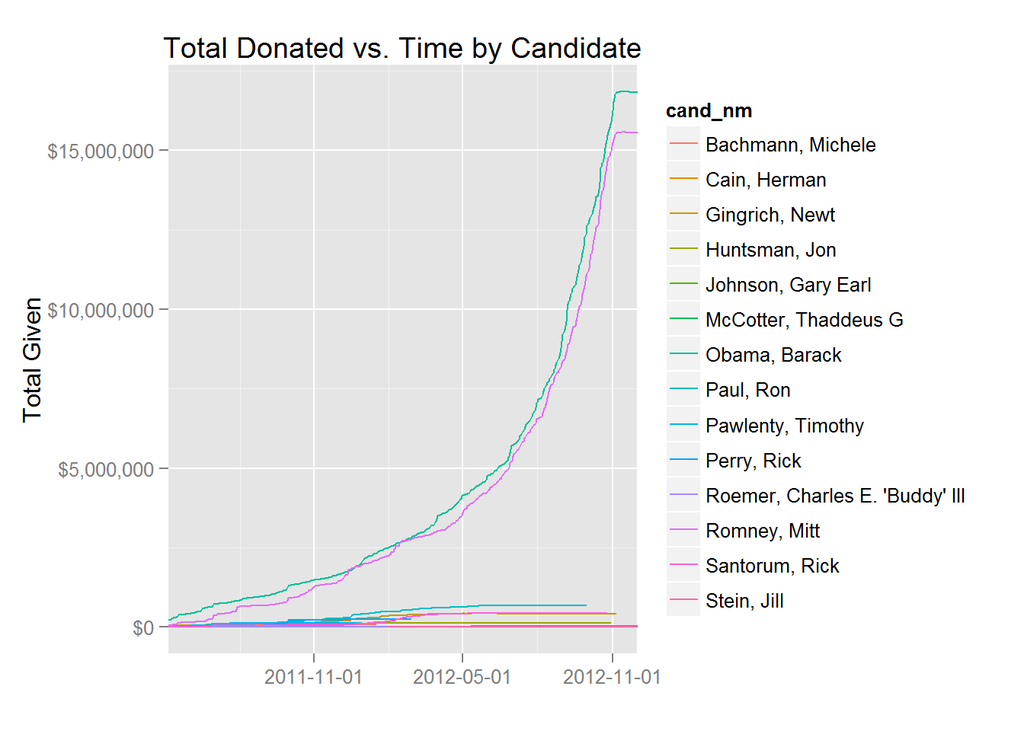

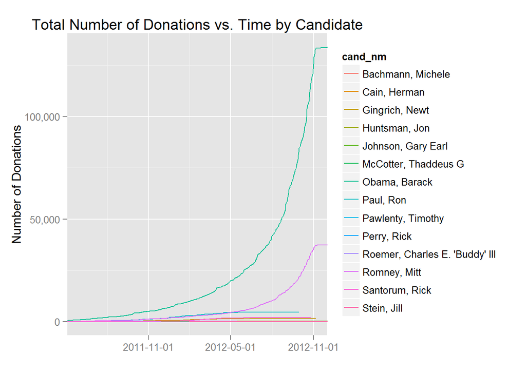

This is the time series for contribtuions to all candidates. Obama ended up with the overall advantgae, but Romney Came very close in August. In September Obama starded to regain the lead.

### Giving Patterns by Time

The motivation for the following three graphs is to see the running total for the amount given to Republican candidates vs. Democrats, and to see the number discreet contributions.

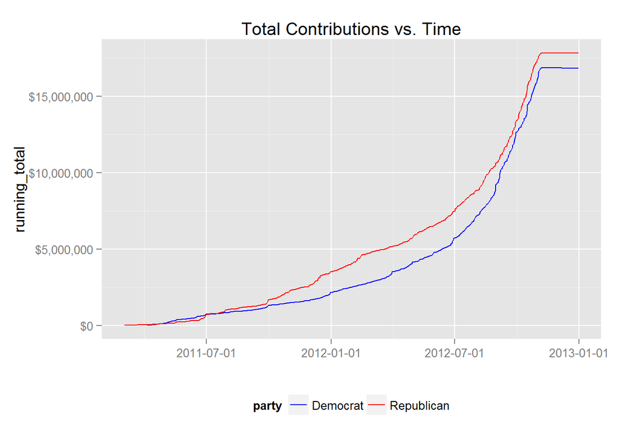

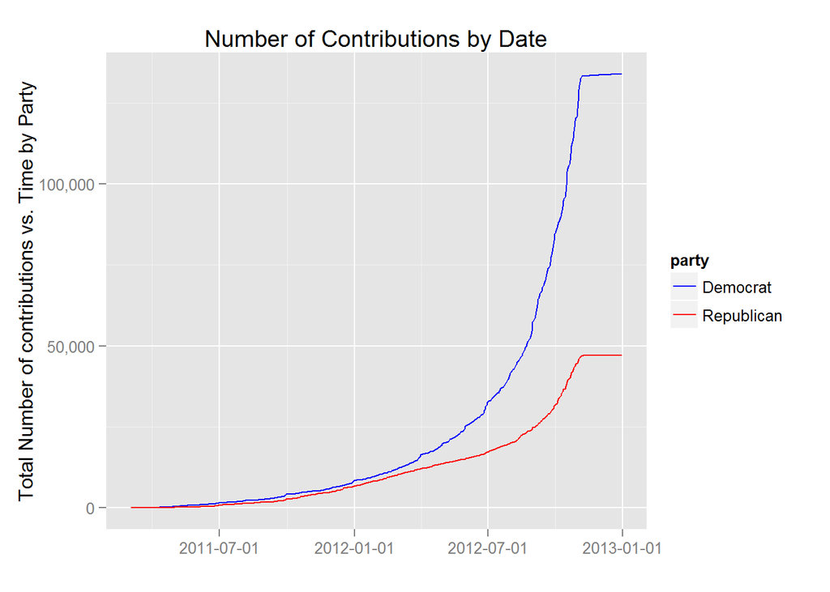

```
## List of 1
##  $ legend.position: chr "bottom"
##  - attr(*, "class")= chr [1:2] "theme" "gg"
##  - attr(*, "complete")= logi FALSE
```

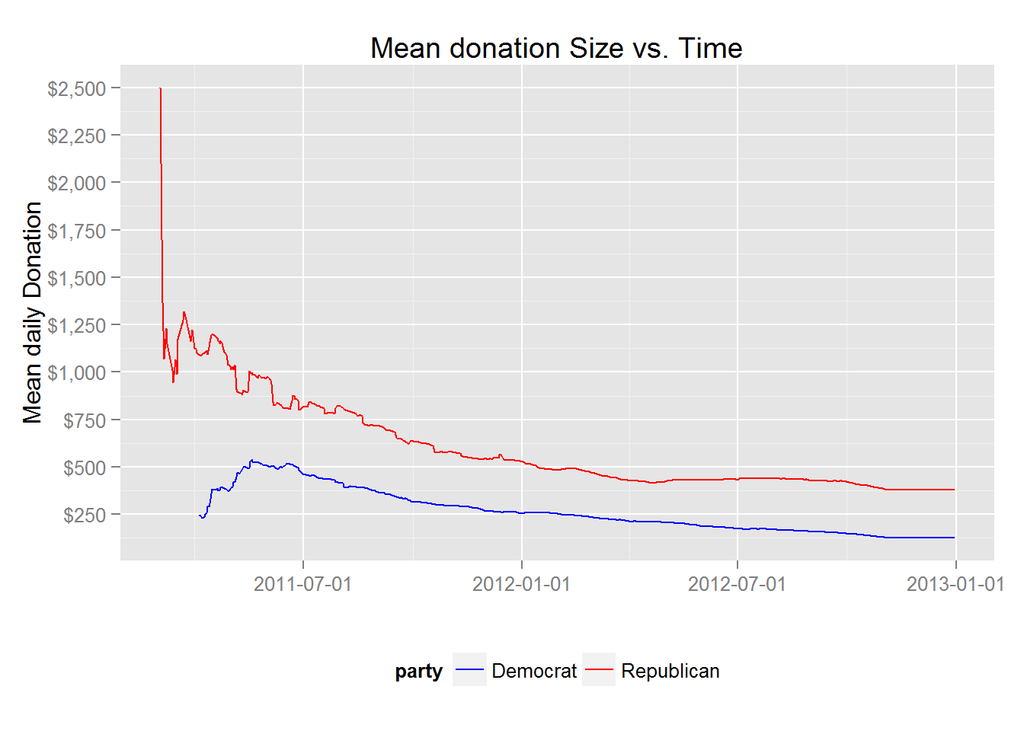

### Key Observations:

Republicans dnations were higher, partialyl due to the primary, but also because of large momentum between January 1 and April 1. After that, things seem to slow down, and in mid-summer (July onward), Obama began to close the fundraising gap. this was mostly done by the number of contributions, which we see in the ‘Total Number of Contributions vs. Time’ graph. An interesting point, however, is that the average size of donations seems to have a slightly negative correlation with time. So democrats were giving more often, but we steadily giving much much less than Republicans.

I want to see if these relationships, and other, are for different professions.

### A side note:

```
## [1] 667
```

```
## Source: local data frame [9 x 3]
##
##             cand_nm total_max percent_total
## 1      Romney, Mitt       479    0.71814093
## 2       Perry, Rick        59    0.08845577
## 3    Gingrich, Newt        35    0.05247376
## 4 Pawlenty, Timothy        28    0.04197901
## 5     Huntsman, Jon        22    0.03298351
## 6         Paul, Ron        19    0.02848576
## 7      Cain, Herman        13    0.01949025
## 8    Santorum, Rick        11    0.01649175
## 9 Bachmann, Michele         1    0.00149925
```

## Analysis of Giving by Professions

I built a function to search for key words that fit in certain proffessions and then filtered and buil a series of plots.

for each group I present: summary distribution

total given

number of contributors

### Armed Services

```
##    Min. 1st Qu.  Median    Mean 3rd Qu.    Max.
##     4.0   120.0   250.0   500.7   500.0  5700.0
```

```
## [1] 221303
```

```
## [1] 442
```

### Medical Professionals

```
##    Min. 1st Qu.  Median    Mean 3rd Qu.    Max.
##     8.0   195.8   300.0   608.8   648.5  5200.0
```

```
## [1] 1068975
```

```
## [1] 1756
```

### Educators

```
##    Min. 1st Qu.  Median    Mean 3rd Qu.    Max.
##     0.0   105.0   250.0   487.1   500.0  5475.0
```

```
## [1] 1102288
```

```
## [1] 2263
```

### Legal Professionals

```
##    Min. 1st Qu.  Median    Mean 3rd Qu.    Max.
##     0.0   250.0   500.0   963.4  1030.0 10000.0
```

```
## [1] 3470322
```

```
## [1] 3602
```

### Running total

This is a graph of the time series for the four professions

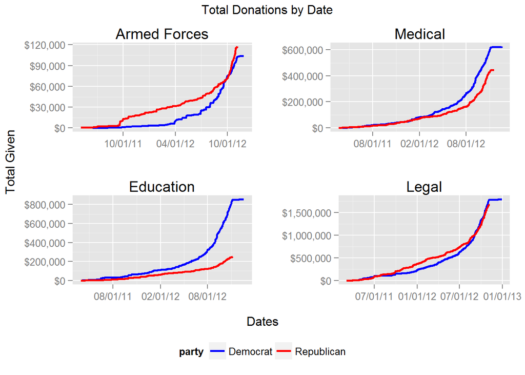

### Depiction of Giving Distribution by Professions

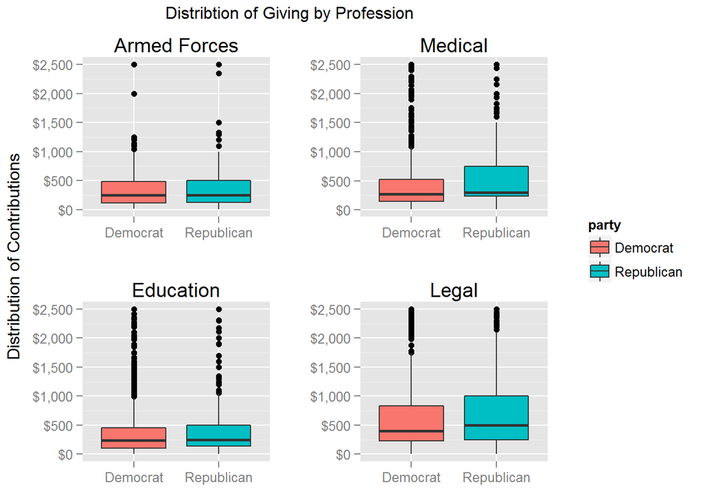

The side by side comparison is that different except for legal professionals. Republican lawyers, judges, etc. give a LOT more than the general population. The other professions medical is higher, but not that much more.

### Density distribution of political donations by professions and party

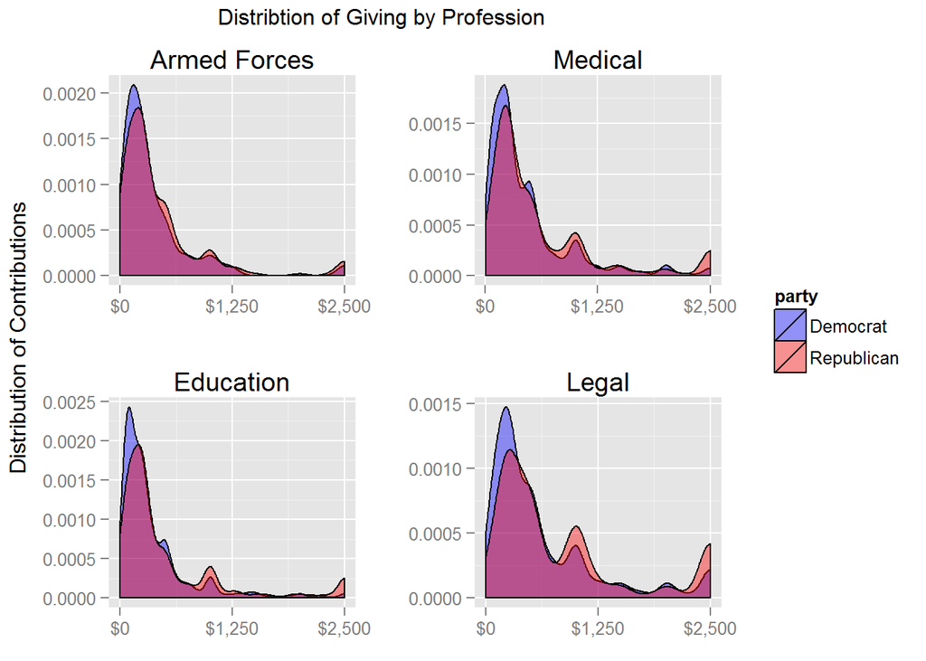

# Final Plots and Summary

### Plot One

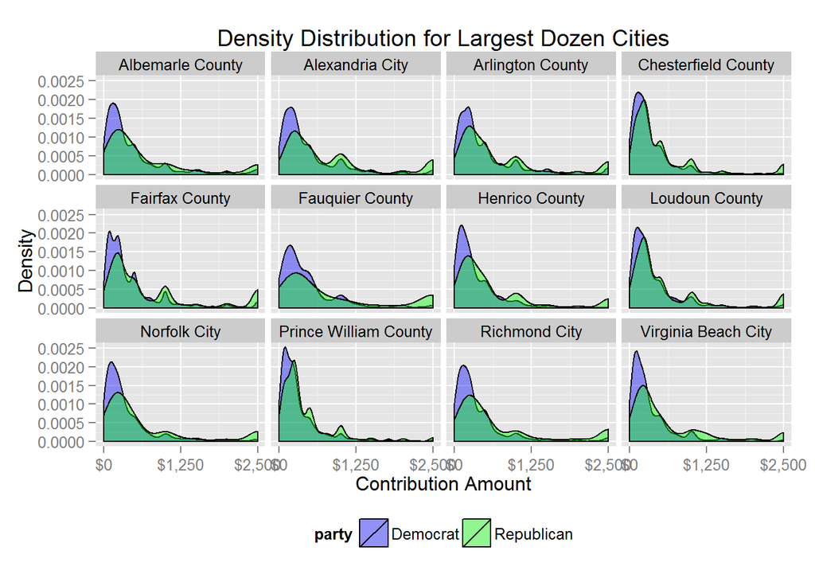

### Description One

With the onset of PACs, where affluent individuals can disproprtionately impact races, this is a much smaller consideration.

It was nonetheless, a very close race (51.16 vs. 47.28)

### Plot Two

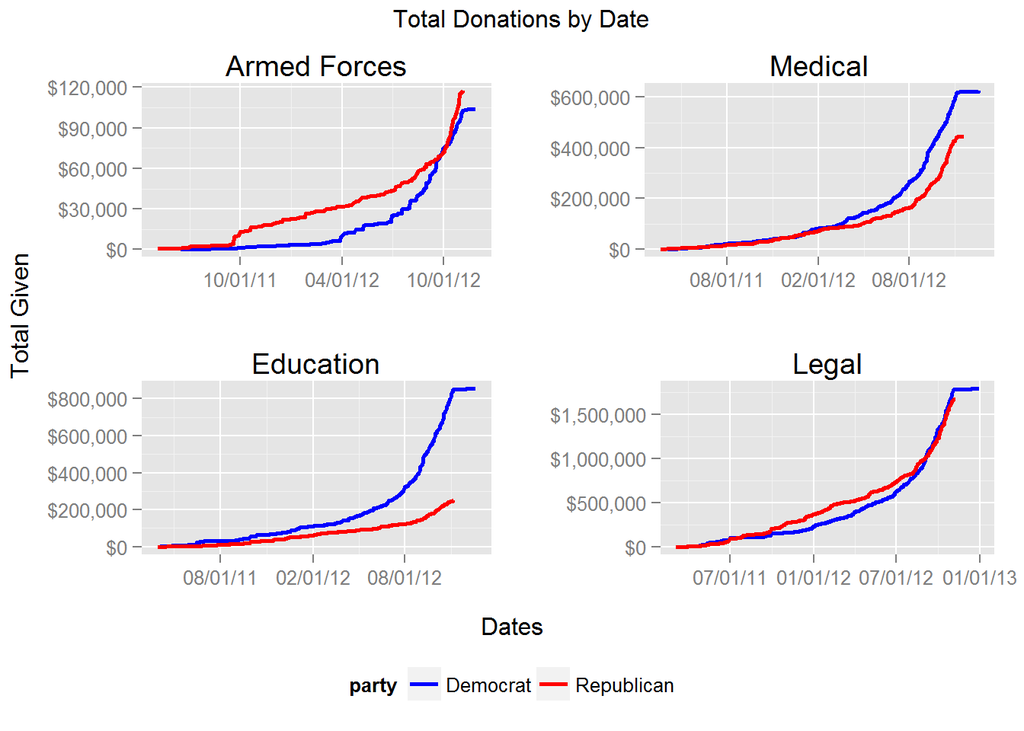

### Description Two

This is a plot of the four major professions and their giving totals for both parties based on time. Wesome interesting changes in the personal contributions. There seemed to be a crucial point when democratic giving took over for members of the legal profession.

It was interesting to see medical professional be relatively close in February 2012, but then start to contribut much more to democrats.

For Lawyers, it was the opposite, they began to contribute to Obama starting in July,and eventually democratic contributions overtook Republican ones. Their support was probably crucial.

### Plot Three: Box plot of the four professions

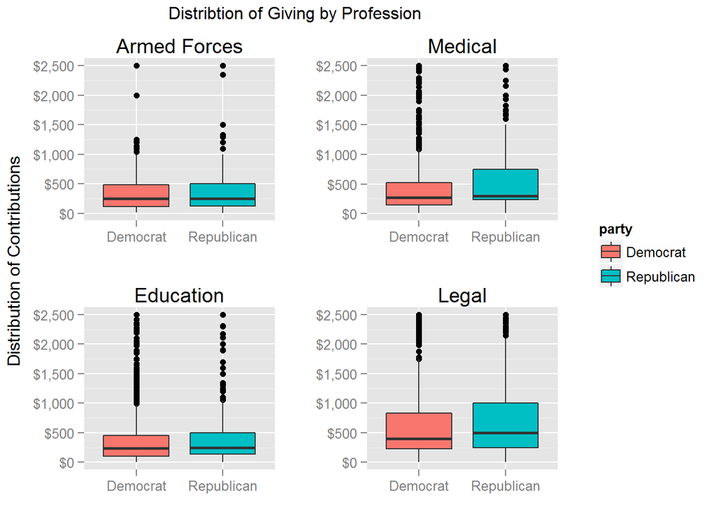

### Description Three

This is an important distribution because it shows that lawyers, on average contribute much more than other professsions, even for democrats. Interestingly

Interestingly, educator and armed forces officials have similar distributions in their giving patterns. This could be because both professions have a lower ceiling and there i not as much variability in the salary. They did deviate from the overall distributions in that their distribution of donations was nearly identical for both parties.

# Reflection

This was a tough data set to work with. There is a lot of room for error in data collection. I didn’t have more time to go through more and ensure that there were more dupliates. I think that I will write some sort of function ( or find a package) to use percentage completion of the name with other variables to furhter join the data.

Large single-donors tend to favor republic candidates. The military tends to favor Republicans. Teachers favor democrats. We did, however, see different infection points. People in the medical profession began to support Obama earlier than lawyers. This data could help campaign managers to evaluate messaging. For example, why did doctors to start supporting Obama heavily? Why did professionals in the legal field take until nearly the end of the race to begin to supportthe encombant. The data could help to reflect on how demographics responde to campaign messages.

Finally, I’m not certain about the lag in reporting the receipt dates. It seems to me like they could possibly be delayed, especially because some were recorded AFTer the election. The lag in processing could impact the reliability of the time series plots.

I made an effort to create a general solution where I could package in another state and perform analasys as quickly. I think that is possible, and I used the “assign” function in the beginning of doing just that, but there I was losing track of the ultimate goal.

The loop filter function was an idea that I used early and kind of grandfathere, in retrospect, it would have been better to try and made a generalized professions and then I could have done much better data wrangling. The variety of professions, was quite overwhelming so I decided to use the filter, even though there is likely overlap. Some military people are probabyl listed as “professor at west point”. Some doctors may be “Medical school professors”. I still felt it was worht it to try, ad a quick glance at the data generally supports the task.

Finally,I think the chloropleth could have been better used. I used the Chloroplethr package, but it has limitations that I couldn’t overcome, namely creating state objects in order to modify with ggplot commands, as per the documentation. Because I couldn’t use ggplot commands, I was stuck with blue, and I felt that additional use of the chloropleth would just lead to conclusion.